# Forest Fires

Dominik Szczepaniak

2/21/2021

## Forest Fires Analysis

This article will analyse a dataset on forest fires in Portugal. It is focused entirely on practice of data visualisation, so any data cleaning was omitted. The dataset was provided by Dataquest as part of their Data Analyst in R path. First, we need to get the data:

```r
library(tidyverse)
fires <- read_csv("forestfires.csv")
```

```r
colnames <- colnames(fires)
colnames
```

```
##  [1] "X"     "Y"     "month" "day"   "FFMC"  "DMC"   "DC"    "ISI"   "temp"
## [10] "RH"    "wind"  "rain"  "area"
```

There are two character variables for month and day, let’s see whether they are ordered correctly:

```r
fires %>% pull(month) %>% unique
```

```
##  [1] "mar" "oct" "aug" "sep" "apr" "jun" "jul" "feb" "jan" "dec" "may" "nov"
```

```r
fires %>% pull(day) %>% unique
```

```
## [1] "fri" "tue" "sat" "sun" "mon" "wed" "thu"
```

They aren’t, but it will be fixed:

```r
fires <- fires %>%
  mutate(
    month = factor(month, levels = c("jan","feb", "mar", "apr", "jun", "jul", "aug", "sep", "oct", "nov", "dec")),
    day = factor(day, levels = c("mon", "tue", "wed", "thu", "fri", "sat", "sun"))
    )
```

I want to see the number of fires per month and per day.

```r
fires_per_month <-  fires %>%
  group_by(month) %>%
  summarise(
    counter = n()
    )
fires_per_month
```

```
## # A tibble: 12 x 2
##    month counter
##  * <fct>   <int>
##  1 jan         2
##  2 feb        20
##  3 mar        54
##  4 apr         9
##  5 jun        17
##  6 jul        32
##  7 aug       184
##  8 sep       172
##  9 oct        15
## 10 nov         1
## 11 dec         9
## 12 <NA>        2
```

```r
fires_per_day <- fires %>%
  group_by(day) %>%
  summarise(
    counter = n()
    )
fires_per_day
```

```
## # A tibble: 7 x 2
##   day   counter
## * <fct>   <int>
## 1 mon        74
## 2 tue        64
## 3 wed        54
## 4 thu        61
## 5 fri        85
## 6 sat        84
## 7 sun        95
```

I will now visualise both these using bar charts:

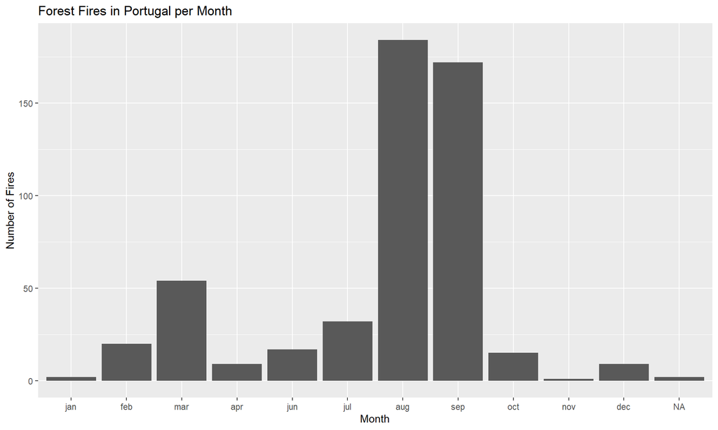

```r
fires_per_month %>%
  ggplot(aes(x = month, y = counter)) +
  geom_col() +
  labs(
    title = "Forest Fires in Portugal per Month",
    x = "Month",
    y = "Number of Fires"
  )
```

By far the most fires occur in August and September.

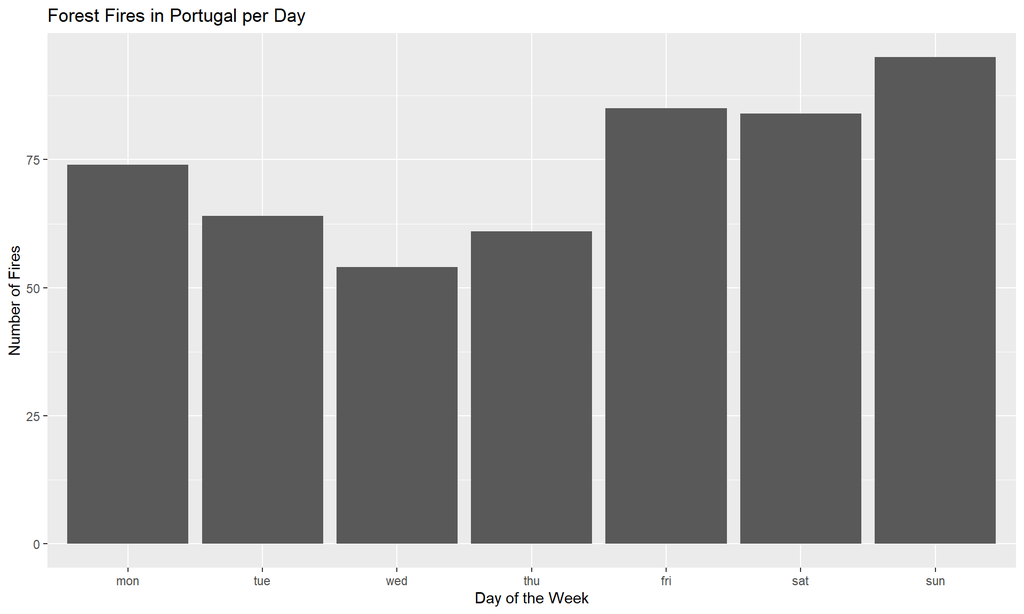

```r
fires_per_day %>%
  ggplot(aes(x = day, y = counter)) +
  geom_col() +
  labs(
    title = "Forest Fires in Portugal per Day",
    x = "Day of the Week",
    y = "Number of Fires"
  )
```

Most fires tend to happen on the weekends.

It’s important to see which of the parameters related to forest fires see their rise in August and September so that the reasons for that spike can be tracked.

```r
fires_long <- fires %>%
  pivot_longer(cols = c("FFMC", "DMC", "DC", "ISI", "temp", "RH", "wind", "rain"),
    names_to = "parameters",
    values_to = "value"
    )
```

Let’s plot this:

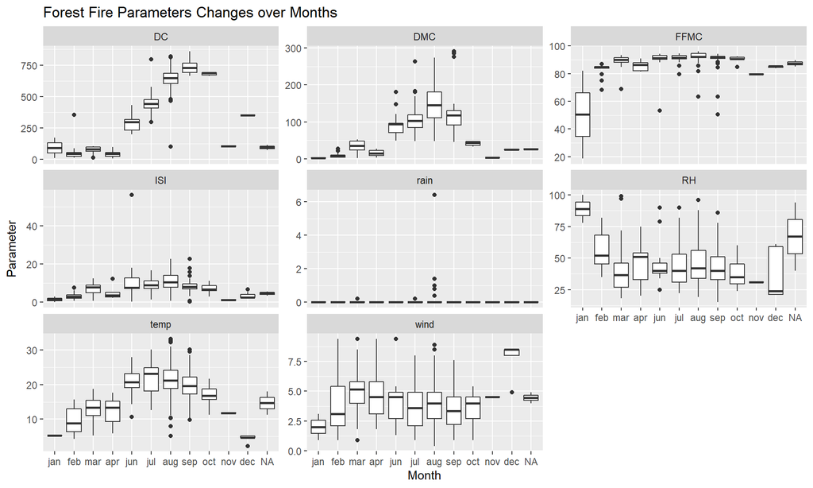

```r
fires_long %>%
  ggplot(aes(x = month, y = value)) +
  geom_boxplot() +
  facet_wrap(vars(parameters), scale = "free_y") +
  labs(
    title = "Forest Fire Parameters Changes over Months",
    x = "Month",
    y = "Parameter"
  )
```

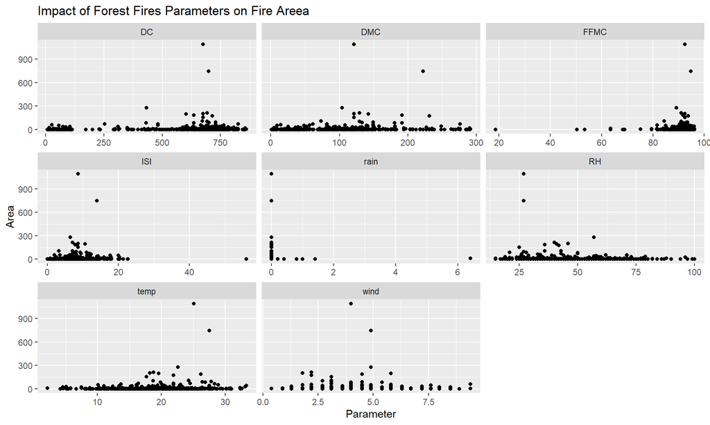

```r
fires_long %>%
  ggplot(aes(x = value, y = area)) +
  geom_point() +
  facet_wrap(vars(parameters), scale = "free_x") +
  labs(
    title = "Impact of Forest Fires Parameters on Fire Areea",
    x = "Parameter",
    y = "Area"
  )
```

Parameters such as ISI and FFMC seem to have the biggest impact on the area of forest fires.